# Email statistics

# Background and definitions

iModules is the system used to send mass emails to Northwestern constituents, including alumni. Detailed email recipient, bounce, open, and click data is available for 480 days after an email is sent; after that time, only summary statistics are available.

The metrics are defined as follows:

- **Delivered** = 200 HTTP status code response from server, e.g. the request was fulfilled (*delivered does not imply inbox placement*)
- **Bounces** = email addresses that could not be successfully delivered to the recipient’s inbox for some reason
- **Open** = tracking pixel loaded (*implying that image blocking or plain-text email clients leads to underreporting of opens*)
- **Click** = number of times any recipient clicks on any link within the email where tracking is active (*excluding the unsubscribe link*)

# iModules summary statistics

## Businessweek

| Email Type | Program | Grad Year | Date Sent | Sent | Bounces | Opens | Open Rate | Clicks* | Unique Clicks | CTR | Unsubs | Drilldown |
| --- | --- | --- | --- | --- | --- | --- | --- | --- | --- | --- | --- | --- |
| Initial Email | 2Y FT | FY09-FY11 | 2018-05-10 | 1420 | 15 | 600 | 42.0% | 158 | 96 | 16.0% | 0 | N |
| Reminder | 2Y FT | FY09-FY11 | 2018-06-09 | 1414 | 7 | 548 | 39.0% | 127 | 105 | 19.0% | 0 | N |
| Reminder | 2Y FT | FY09-FY11 | 2018-06-24 | 1400 | 1 | 560 | 40.0% | 75 | 71 | 13.0% | 0 | N |
| Reminder | 2Y FT | FY09-FY11 | 2018-06-29 | 1384 | 1 | 416 | 30.0% | 54 | 51 | 12.0% | 0 | N |
| Initial Email | 2Y FT | FY13 | 2019-04-25 | 460 | 2 | 205 | 45.0% | 43 | 42 | 20.0% | 0 | Y |
| Reminder | 2Y FT | FY13 | 2019-07-11 | 458 | 1 | 211 | 46.0% | 57 | 46 | 22.0% | 0 | Y |

## Economist

| Email Type | Program | Grad Year | Date Sent | Sent | Bounces | Opens | Open Rate | Clicks* | Unique Clicks | CTR | Unsubs | Drilldown |
| --- | --- | --- | --- | --- | --- | --- | --- | --- | --- | --- | --- | --- |
| Initial Email | Domestic EMBA | FY17 | 2018-04-05 | 210 | 1 | 156 | 74.0% | 73 | 68 | 44.0% | 0 | N |
| Resend* | Domestic EMBA | FY15-17 | 2018-04-29 | 329 | 5 | 235 | 71.0% | 124 | 92 | 39.0% | 0 | N |
| Reminder | Domestic EMBA | FY15-17 | 2018-05-05 | 329 | 3 | 198 | 60.0% | 51 | 47 | 24.0% | 0 | N |
| Reminder | Domestic EMBA | FY15 | 2018-05-12 | 168 | 2 | 81 | 48.0% | 20 | 19 | 23.0% | 0 | N |
| Initial Email | 2Y FT | FY2017 | 2018-06-09 | 387 | 1 | 261 | 67.0% | 72 | 69 | 26.0% | 0 | N |
| Initial Email | 2Y FT | FY2018 | 2019-04-16 | 478 | 0 | 364 | 76.0% | 166 | 132 | 36.0% | 0 | Y |
| Reminder | 2Y FT | FY2018 | 2019-05-06 | 477 | 0 | 310 | 65.0% | 56 | 52 | 17.0% | 0 | Y |

## Financial Times

| Email Type | Program | Grad Year | Date Sent | Sent | Bounces | Opens | Open Rate | Clicks* | Unique Clicks | CTR | Unsubs | Drilldown |
| --- | --- | --- | --- | --- | --- | --- | --- | --- | --- | --- | --- | --- |
| Initial Email | Domestic EMBA | FY15 | 2018-05-27 | 178 | 1 | 122 | 69.0% | 34 | 27 | 22.0% | 0 | N |
| Initial Email | Domestic EMBA | FY16 | 2019-06-09 | 190 | 0 | 155 | 82.0% | 14 | 14 | 9.0% | 0 | Y |
| Reminder | Domestic EMBA | FY16 | 2019-07-23 | 189 | 0 | 125 | 66.0% | 0 | 0 | 0.0% | 0 | Y |
| Initial Email | 2Y FT | FY16 | 2019-09-05 | 453 | 2 | 287 | 63.0% | 11 | 11 | 4.0% | 0 | Y |

## Forbes

| Email Type | Program | Grad Year | Date Sent | Sent | Bounces | Opens | Open Rate | Clicks* | Unique Clicks | CTR | Unsubs | Drilldown |
| --- | --- | --- | --- | --- | --- | --- | --- | --- | --- | --- | --- | --- |
| Initial Email | 2Y FT | FY14 | 2019-04-30 | 476 | NA | NA | NA% | NA | NA | NA% | NA | N |
| Initial Email | 2Y FT | FY14 | 2019-05-16 | 477 | NA | NA | NA% | NA | NA | NA% | NA | N |

Forbes email metrics are not available, as the emails were sent through Outlook rather than iModules (recipients had personalized links).

Overall, the bounce rates are surprisingly low, and the open/click rates quite high.

# Computed summary statistics

As a point of comparison, I pulled a full class list from the database. Now, the unit of analysis is individuals rather than emails. Individuals are categorized by the set of emails received, e.g. Economist 2018 FT is full-time 2018 graduates emailed about the Economist.

If an individual opened either an initial email or a reminder, I counted that as an open; the same goes for clicks. Note that raw counts will be different, as non-alumni recipients (such as KSM staff) are filtered out, unlike in the summary statistics above.

| email_group | n | sent | bounced | opened | clicked | sent_pct | open_pct | clicked_pct |
| --- | --- | --- | --- | --- | --- | --- | --- | --- |
| Businessweek 2013 FT | 457 | 457 | 1 | 262 | 74 | 100.0% | 57.3% | 28.2% |
| Economist 2018 FT | 474 | 474 | 0 | 406 | 174 | 100.0% | 85.7% | 42.9% |
| Financial Times 2016 EMBA | 185 | 185 | 0 | 158 | 13 | 100.0% | 85.4% | 8.2% |
| Financial Times 2016 FT | 450 | 450 | 0 | 285 | 11 | 100.0% | 63.3% | 3.9% |
| None | 50 | 2 | 2 | 0 | 0 | 4.0% | 0.0% | 0.0% |

Drilling down into this None group:

| FIRST_MASTERS_YEAR | PROGRAM_GROUP | n |
| --- | --- | --- |
| 2013 | Full-Time | 25 |
| 2016 | EMBA | 7 |
| 2016 | Full-Time | 13 |
| 2018 | Full-Time | 5 |

Adding these groups to the above table yields the following.

| email_group_filled | n | sent | bounced | opened | clicked | sent_pct | open_pct | clicked_pct |
| --- | --- | --- | --- | --- | --- | --- | --- | --- |
| Businessweek 2013 FT | 482 | 458 | 2 | 262 | 74 | 95.02% | 57.2% | 28.2% |
| Economist 2018 FT | 479 | 474 | 0 | 406 | 174 | 98.96% | 85.7% | 42.9% |
| Financial Times 2016 EMBA | 192 | 185 | 0 | 158 | 13 | 96.35% | 85.4% | 8.2% |
| Financial Times 2016 FT | 463 | 451 | 1 | 285 | 11 | 97.41% | 63.2% | 3.9% |

It’s possible that link tracking was not enabled for Financial Times and the captured clicks were to non-survey links.

# Email address analysis

Just because an email was received doesn’t mean it went to the individual’s inbox (spam filters) or or even to an account still being checked (old address). I’d like to look at opens as a function of email address status (per the database) and email update date.

First, is the email sent to in iModules the same as the person’s current preferred email address in the CATracks database?

| email_group_filled | same_email | n | sent | bounced | opened | clicked | sent_pct | open_pct | clicked_pct |
| --- | --- | --- | --- | --- | --- | --- | --- | --- | --- |
| Businessweek 2013 FT | FALSE | 180 | 156 | 2 | 69 | 14 | 86.7% | 44.2% | 20.3% |
| Businessweek 2013 FT | TRUE | 302 | 302 | 0 | 193 | 60 | 100.0% | 63.9% | 31.1% |
| Economist 2018 FT | FALSE | 27 | 22 | 0 | 18 | 11 | 81.5% | 81.82% | 61.1% |
| Economist 2018 FT | TRUE | 452 | 452 | 0 | 388 | 163 | 100.0% | 85.84% | 42.0% |
| Financial Times 2016 EMBA | FALSE | 18 | 11 | 0 | 7 | 1 | 61.1% | 63.6% | 14.29% |
| Financial Times 2016 EMBA | TRUE | 174 | 174 | 0 | 151 | 12 | 100.0% | 86.8% | 7.95% |
| Financial Times 2016 FT | FALSE | 65 | 53 | 1 | 29 | 1 | 81.5% | 54.72% | 3.448% |
| Financial Times 2016 FT | TRUE | 398 | 398 | 0 | 256 | 10 | 100.0% | 64.32% | 3.906% |

## Open rates

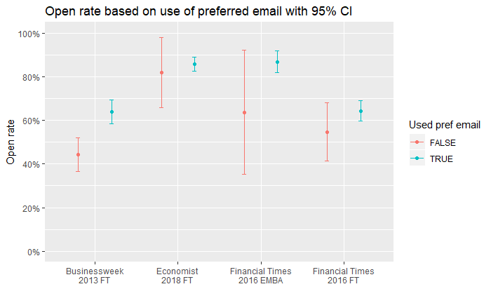

There appears to be a strong main effect for `same_email == TRUE`. Also note that all bounces, and not sent, emails are ones that weren’t sent to the preferred email address per the database.

Other potentially important variables could be the email address status and date last updated.

| email_group_filled | send_email_status | n | sent | bounced | opened | clicked | sent_pct | open_pct | clicked_pct |
| --- | --- | --- | --- | --- | --- | --- | --- | --- | --- |
| Businessweek 2013 FT | Active | 412 | 412 | 1 | 245 | 68 | 100.0% | 59.5% | 27.8% |
| Businessweek 2013 FT | Inactive | 10 | 10 | 0 | 4 | 2 | 100.0% | 40.0% | 50.0% |
| Businessweek 2013 FT | NA | 60 | 36 | 1 | 13 | 4 | 60.0% | 36.1% | 30.8% |
| Economist 2018 FT | Active | 470 | 470 | 0 | 403 | 172 | 100.0% | 85.7% | 42.7% |
| Economist 2018 FT | NA | 9 | 4 | 0 | 3 | 2 | 44.4% | 75.0% | 66.7% |
| Financial Times 2016 EMBA | Active | 177 | 177 | 0 | 152 | 12 | 100.0% | 85.9% | 7.9% |
| Financial Times 2016 EMBA | Inactive | 1 | 1 | 0 | 0 | 0 | 100.0% | 0.0% | 0.0% |
| Financial Times 2016 EMBA | NA | 14 | 7 | 0 | 6 | 1 | 50.0% | 85.7% | 16.7% |
| Financial Times 2016 FT | Active | 447 | 447 | 0 | 285 | 11 | 100.0% | 63.8% | 3.86% |
| Financial Times 2016 FT | Inactive | 2 | 2 | 0 | 0 | 0 | 100.0% | 0.0% | 0.00% |

[output cut: 1 more lines]

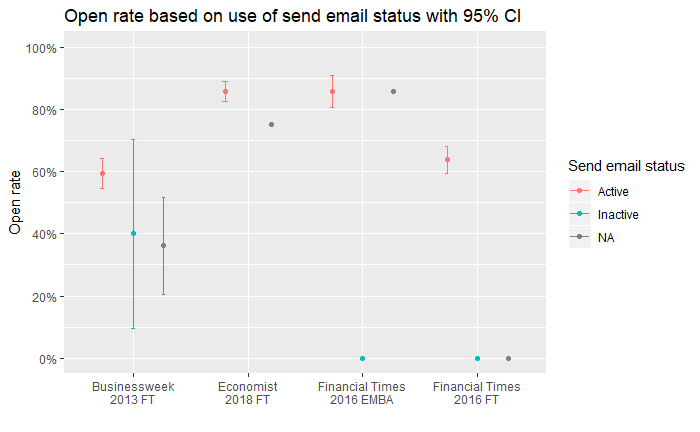

Here, NA corresponds to emails not from the database. Again, note that these emails have the worst performance (with one exception due to expected small-sample variance).

Finally, consider open rate as a function of email age.

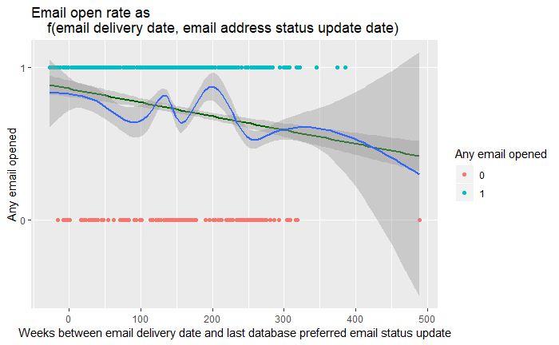

This is actually pretty interesting – there’s an overall decreasing trend, with spikes around certain update times. I suspect a class year effect, so partitioning this out by email:

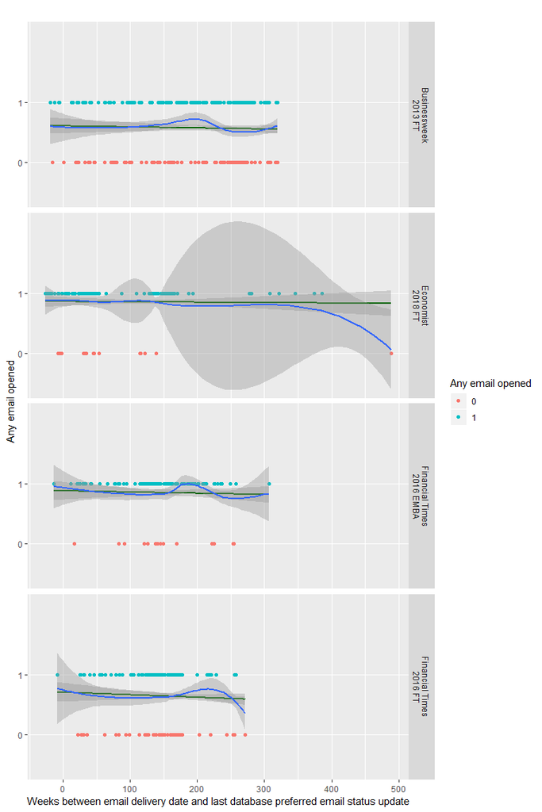

Interestingly, the peaks are within about the same time period, a little under 4 years before the last email was sent. Looking instead at the raw email update time data gives the following:

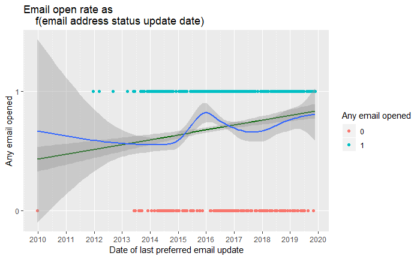

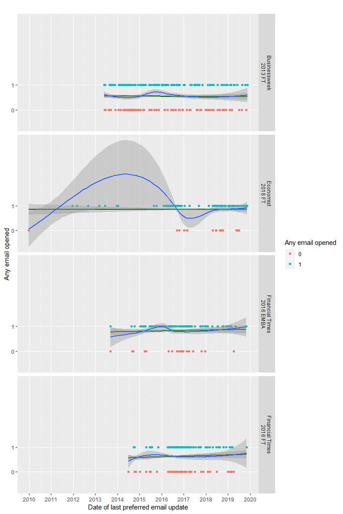

So around 4 years ago from summer 2015 to summer 2016 a bunch of good emails were captured, even from the class of 2013? Peculiar.

Plugging this all into a quick and simple model:

```
Call:
glm(formula = any_open ~ email_group_filled + same_email + send_email_status +
    ns(weeks_since_email, df = 4), family = binomial(), data = .)

Deviance Residuals:
    Min       1Q   Median       3Q      Max
-2.1039  -1.1337   0.5533   0.8563   1.5485

Coefficients:
                                            Estimate Std. Error z value Pr(>|z|)
(Intercept)                                   0.7966     0.4469   1.782   0.0747 .
email_group_filledEconomist 2018 FT           1.0921     0.1970   5.544 2.95e-08 ***
email_group_filledFinancial Times 2016 EMBA   1.1119     0.2461   4.517 6.27e-06 ***
email_group_filledFinancial Times 2016 FT    -0.1722     0.1658  -1.039   0.2990
same_emailTRUE                                0.6773     0.1629   4.158 3.22e-05 ***
send_email_statusInactive                    -1.2849     0.6151  -2.089   0.0367 *
send_email_statusNA                          -0.5400     0.3328  -1.623   0.1047
ns(weeks_since_email, df = 4)1               -0.3040     0.4009  -0.758   0.4482
ns(weeks_since_email, df = 4)2               -0.6628     0.5027  -1.318   0.1874
ns(weeks_since_email, df = 4)3               -2.6845     1.1738  -2.287   0.0222 *
ns(weeks_since_email, df = 4)4               -0.5985     1.4694  -0.407   0.6838
---
Signif. codes:  0 ‘***’ 0.001 ‘**’ 0.01 ‘*’ 0.05 ‘.’ 0.1 ‘ ’ 1

(Dispersion parameter for binomial family taken to be 1)

    Null deviance: 1882.9  on 1561  degrees of freedom
Residual deviance: 1719.2  on 1551  degrees of freedom
  (54 observations deleted due to missingness)
AIC: 1741.2

Number of Fisher Scoring iterations: 4
```

Note that the reference factor levels were Businessweek; sending emails to a non-preferred address; and email status active.

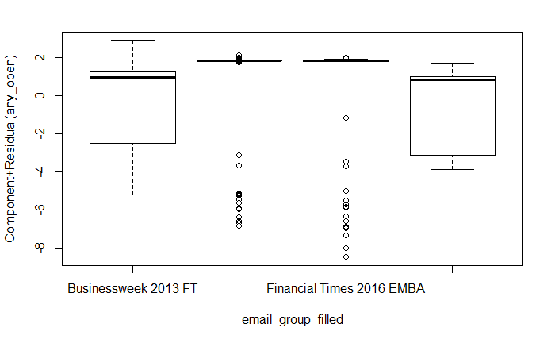

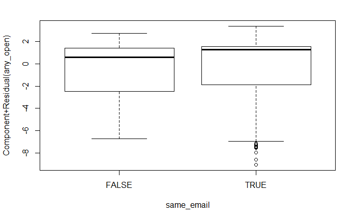

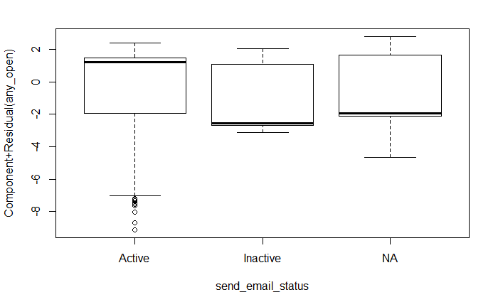

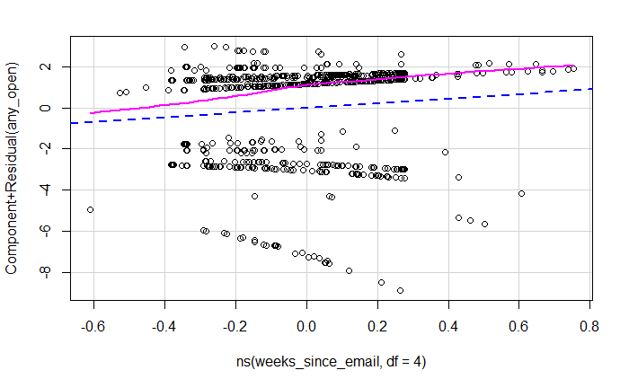

## Clicks

Now consider the same analyses with click data.

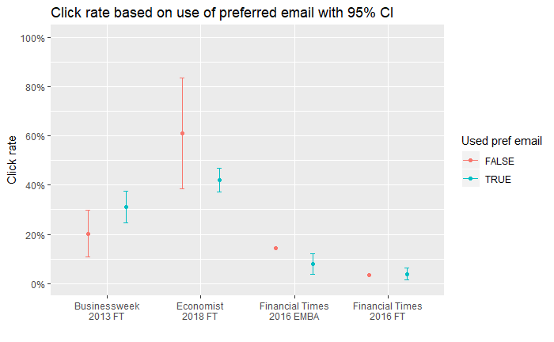

Note that the click rates are very low for the Financial Times surveys; again, I wonder whether the data was not captured correctly. These two should probably be modeled separately from the others.

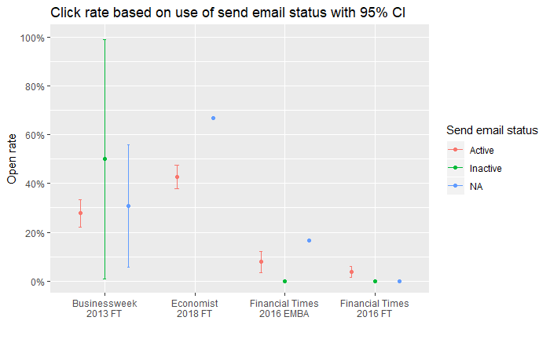

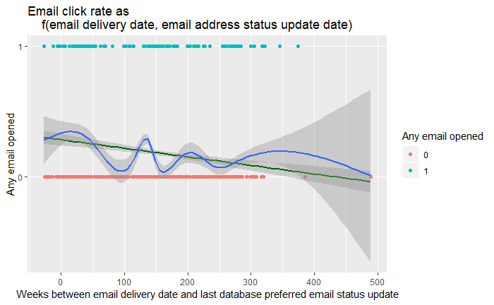

Looks like the same trend as for opens, just the click rate starts much lower. Ignoring the two Financial Times surveys:

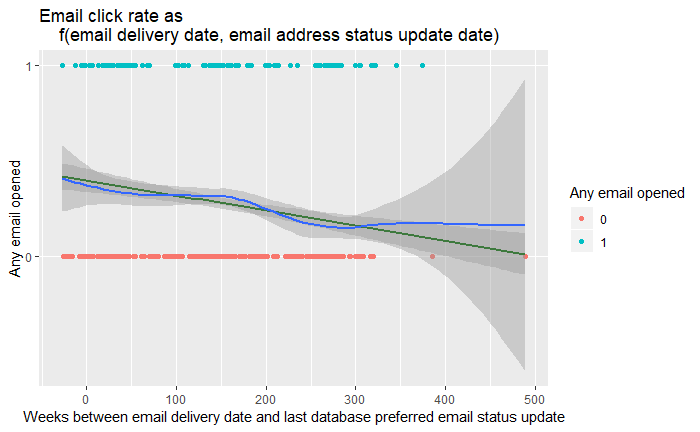

So the noisiness was pretty much all due to Financial Times. Now breaking things out by publication:

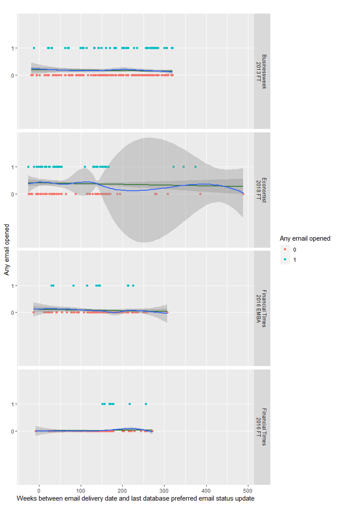

And finally trying a quick model:

```
Call:
glm(formula = any_open ~ email_group_filled + same_email + send_email_status +
    ns(weeks_since_email, df = 4), family = binomial(), data = .)

Deviance Residuals:
    Min       1Q   Median       3Q      Max
-1.9892  -1.0268   0.5492   0.7865   1.5732

Coefficients:
                                    Estimate Std. Error z value Pr(>|z|)
(Intercept)                           0.7631     0.5148   1.482 0.138212
email_group_filledEconomist 2018 FT   1.1761     0.2128   5.527 3.26e-08 ***
same_emailTRUE                        0.7945     0.2060   3.856 0.000115 ***
send_email_statusInactive            -0.8714     0.6674  -1.306 0.191683
send_email_statusNA                  -0.5197     0.3683  -1.411 0.158240
ns(weeks_since_email, df = 4)1       -0.2361     0.4560  -0.518 0.604564
ns(weeks_since_email, df = 4)2       -0.4585     0.6797  -0.675 0.499952
ns(weeks_since_email, df = 4)3       -3.4375     1.4219  -2.418 0.015624 *
ns(weeks_since_email, df = 4)4       -1.0586     1.6545  -0.640 0.522293
---
Signif. codes:  0 ‘***’ 0.001 ‘**’ 0.01 ‘*’ 0.05 ‘.’ 0.1 ‘ ’ 1

(Dispersion parameter for binomial family taken to be 1)

    Null deviance: 1104.58  on 927  degrees of freedom
Residual deviance:  982.85  on 919  degrees of freedom
  (33 observations deleted due to missingness)
AIC: 1000.9

Number of Fisher Scoring iterations: 4
```

So email status doesn’t provide any information beyond knowing that the preferred email was used.

```
Call:
glm(formula = any_open ~ email_group_filled + same_email + ns(weeks_since_email,
    df = 4), family = binomial(), data = .)

Deviance Residuals:
    Min       1Q   Median       3Q      Max
-1.9953  -1.0710   0.5507   0.7932   1.3919

Coefficients:
                                    Estimate Std. Error z value Pr(>|z|)
(Intercept)                           0.7328     0.5142   1.425   0.1542
email_group_filledEconomist 2018 FT   1.1979     0.2119   5.653 1.58e-08 ***
same_emailTRUE                        0.8653     0.1982   4.367 1.26e-05 ***
ns(weeks_since_email, df = 4)1       -0.2825     0.4555  -0.620   0.5351
ns(weeks_since_email, df = 4)2       -0.5432     0.6780  -0.801   0.4230
ns(weeks_since_email, df = 4)3       -3.5880     1.4151  -2.535   0.0112 *
ns(weeks_since_email, df = 4)4       -1.0245     1.6611  -0.617   0.5374
---
Signif. codes:  0 ‘***’ 0.001 ‘**’ 0.01 ‘*’ 0.05 ‘.’ 0.1 ‘ ’ 1

(Dispersion parameter for binomial family taken to be 1)

    Null deviance: 1104.58  on 927  degrees of freedom
Residual deviance:  986.49  on 921  degrees of freedom
  (33 observations deleted due to missingness)
AIC: 1000.5

Number of Fisher Scoring iterations: 4
```

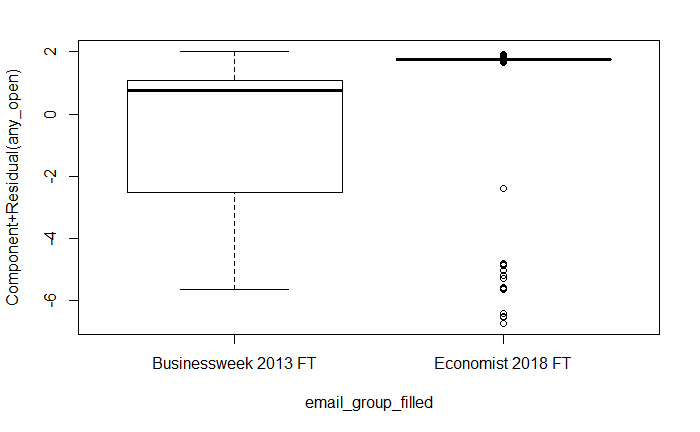

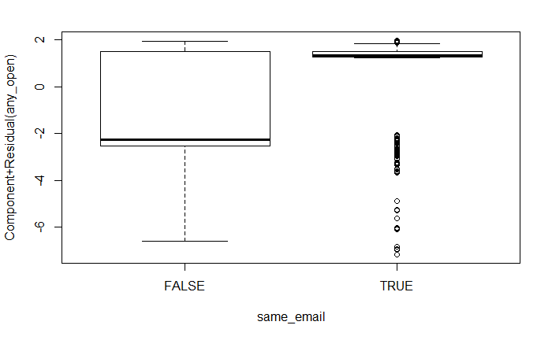

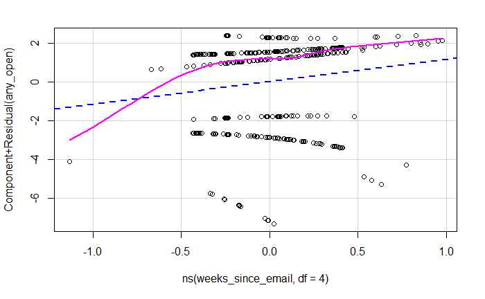